# Data Analysis for Research

Dr Polla Fattah

2025-04-23

# Part 1: Foundations of Data Analysis

## What Is Data Analysis Beyond Descriptive Statistics?

Descriptive statistics such as means, medians, and standard deviations are essential for summarizing data. However, **true data analysis in research** goes far beyond these initial summaries. It involves asking questions, testing hypotheses, building models, and making evidence-based decisions. While descriptive statistics help you understand “what” your data looks like, deeper data analysis asks **“why”**, **“how”**, and **“what if”**.

Data analysis in the context of research is not just about calculation—it is about **interpretation** and **argumentation**. You analyze data not only to describe a phenomenon but to **validate a claim, support a hypothesis**, or even **challenge existing theories**. It becomes part of the reasoning process behind your research contributions.

## The Role of Data Analysis in Research Validation and Theory Testing

In scientific research, data analysis plays several critical roles:

1. **Testing Hypotheses**: After formulating a hypothesis, analysis helps determine whether the observed data supports or contradicts it.
2. **Evaluating Models**: Statistical models (e.g., regression or classification) help quantify relationships between variables and predict outcomes. Model evaluation through metrics (like R², AUC, or residual plots) provides insight into their reliability.
3. **Generalizing Findings**: Inferential statistics allow you to make generalizations from a sample to a broader population, under uncertainty. This is crucial for research conclusions that aim to contribute to knowledge beyond a single dataset.
4. **Validating Constructs**: When dealing with psychological or social variables (e.g., burnout or satisfaction), data analysis helps assess whether measurement scales actually reflect the concepts they intend to measure. This often involves dimensionality reduction methods such as factor analysis.
5. **Comparing Groups or Conditions**: In experimental or observational research, you often need to compare outcomes across groups or time points. This requires proper use of statistical tests and effect size measures.
6. **Communicating Evidence**: Ultimately, data analysis helps convert raw observations into **structured, communicable insights** that can be peer-reviewed, published, or used to inform policy.

## EDA vs. Inferential vs. Predictive Modeling

Understanding the types of data analysis is essential for selecting the correct approach based on your research question.

### 1. Exploratory Data Analysis (EDA)

EDA is the **first stage of analysis**, where you get familiar with your dataset. It involves: - Summarizing data using descriptive statistics. - Visualizing distributions, correlations, and missing values. - Identifying potential patterns, outliers, or data quality issues.

EDA is **open-ended** and **non-confirmatory**. It helps you form hypotheses and decide which variables may be of interest for deeper analysis.

### 2. Inferential Statistics

Inferential analysis is about **making generalizations**. You apply it when you want to: - Test hypotheses (e.g., “students who sleep less have lower GPA”). - Estimate parameters of a population based on a sample (e.g., average stress level of all graduate students). - Use probability theory to assess how likely your findings are due to chance.

Common tools: t-tests, ANOVA, regression models, confidence intervals, p-values.

### 3. Predictive Modeling

Predictive modeling focuses on **forecasting outcomes**. The goal is not just to understand relationships, but to use them for making predictions about new or future data.

Examples include: - Predicting GPA based on lifestyle factors. - Predicting whether a student is at risk of dropping out using stress, supervisor support, and sleep.

Predictive models often include: - Regression (for continuous outcomes) - Classification (for categorical outcomes) - Machine learning techniques (e.g., decision trees, random forests)

Unlike inferential statistics, predictive models **do not require a focus on significance testing**, but rather on how well the model performs (accuracy, precision, recall, AUC, etc.).

## A Simulated Research Thesis Scenario

To ground our lecture in a realistic academic context, we will follow the case of **Sara**, a Master’s student in Educational Psychology. Her thesis is focused on understanding how lifestyle factors and perceived academic support affect graduate student well-being and academic outcomes.

### Sara’s Research Motivation

Sara noticed among her peers that many graduate students were struggling with mental health issues, academic burnout, and performance pressure. She wanted to investigate whether measurable lifestyle and psychological factors (such as sleep, exercise, stress, and perceived supervisor support) could explain differences in GPA, well-being, or even the risk of academic dropout.

### Thesis Objective

Sara’s thesis aims to:

- Explore the relationships between lifestyle habits, academic pressures, and student performance.
- Predict which students may be at risk of **considering dropout**.
- Identify clusters of students based on shared behavioral or performance profiles.
- Investigate whether psychological and lifestyle variables reflect broader underlying dimensions (e.g., mental health or burnout).

This data analysis lecture will walk through the steps Sara might take as she explores her data and answers each of these objectives with the appropriate analytical techniques.

## Dataset in Use

We will use a simulated dataset called **`graduate_student_wellbeing.csv`**, which contains data collected by Sara as part of her thesis project. This dataset includes responses from 200 graduate students and captures a wide range of variables across academic, psychological, and lifestyle domains.

### Dataset Description

First 15 Students with Simplified Column Names

| Variable | Type | Description |
| --- | --- | --- |
| `student_id` | Categorical | Unique identifier for each student |
| `age` | Numeric | Age in years |
| `gender` | Categorical | Gender (Male or Female) |
| `study_hours_per_week` | Numeric | Self-reported study hours per week |
| `sleep_hours_per_night` | Numeric | Average hours of sleep per night |
| `stress_level` | Ordinal (1–10) | Self-rated stress level |
| `gpa` | Numeric | GPA on a 0.0 to 4.0 scale |
| `caffeine_intake_mg` | Numeric | Daily caffeine intake in milligrams |
| `exercise_freq_per_week` | Numeric | Frequency of physical activity per week |
| `supervisor_support` | Ordinal (1–5) | Perceived level of support from supervisor |
| `mental_health_score` | Numeric | Composite measure of mental well-being (0–100) |
| `burnout_level` | Ordinal (1–10) | Self-assessed burnout level |
| `satisfaction_academic` | Ordinal (1–5) | Academic satisfaction score |
| `considering_dropout` | Binary (0 = No, 1 = Yes) | Whether the student has considered dropping out |

| ID | Age | Gender | StudyHrs | Sleep | Stress | GPA | Caffeine | Exercise | Support | MentalHealth | Burnout | Satisfaction | Dropout |
| --- | --- | --- | --- | --- | --- | --- | --- | --- | --- | --- | --- | --- | --- |
| S001 | 28 | Female | 39.9 | 5.3 | 5 | 2.75 | 224 | 0 | 4 | 63 | 3 | 2 | 0 |
| S002 | 25 | Male | 32.2 | 7.1 | 4 | 3.48 | 203 | 3 | 5 | 55 | 7 | 3 | 0 |
| S003 | 34 | Male | 14.4 | 5.9 | 10 | 3.57 | 130 | 4 | 4 | 65 | 8 | 2 | 0 |
| S004 | 32 | Female | 21.6 | 5.5 | 6 | 2.77 | 120 | 1 | 2 | 56 | 4 | 2 | 0 |
| S005 | 29 | Female | 33.9 | 6.4 | 6 | 2.67 | 178 | 5 | 4 | 63 | 8 | 3 | 0 |
| S006 | 34 | Female | 20.0 | 5.3 | 6 | 3.19 | 286 | 3 | 4 | 80 | 5 | 4 | 1 |
| S007 | 26 | Male | 28.1 | 5.8 | 6 | 2.78 | 229 | 1 | 5 | 45 | 6 | 3 | 0 |
| S008 | 28 | Female | 30.4 | 5.1 | 6 | 3.25 | 147 | 2 | 4 | 77 | 6 | 3 | 0 |
| S009 | 31 | Female | 18.5 | 8.9 | 5 | 3.08 | 249 | 3 | 3 | 80 | 5 | 4 | 0 |
| S010 | 24 | Female | 24.6 | 6.5 | 5 | 2.39 | 0 | 3 | 2 | 58 | 7 | 3 | 1 |
| S011 | 28 | Male | 5.0 | 5.7 | 6 | 3.62 | 283 | 3 | 3 | 28 | 7 | 4 | 0 |
| S012 | 32 | Male | 17.8 | 6.8 | 5 | 3.72 | 23 | 1 | 3 | 51 | 2 | 3 | 0 |
| S013 | 32 | Female | 23.2 | 6.4 | 5 | 2.75 | 147 | 3 | 3 | 79 | 8 | 3 | 0 |
| S014 | 29 | Male | 16.3 | 6.2 | 6 | 2.84 | 79 | 0 | 4 | 60 | 2 | 3 | 0 |
| S015 | 26 | Male | 36.4 | 7.2 | 5 | 3.11 | 63 | 2 | 5 | 45 | 8 | 1 | 0 |

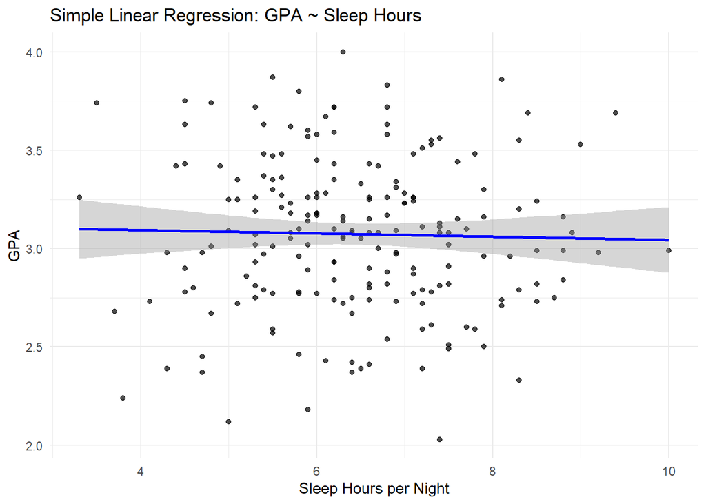

```r
library(ggplot2)
ggplot(data, aes(x = sleep_hours_per_night, y = gpa)) +
  geom_point(alpha = 0.7) +
  geom_smooth(method = "lm", se = TRUE, color = "blue") +
  labs(title = "Simple Linear Regression: GPA ~ Sleep Hours",
       x = "Sleep Hours per Night", y = "GPA") +
  theme_minimal()
```

# Part 3: Regression and Predictive Modeling

Regression is one of the most fundamental tools in data analysis. It allows researchers to **quantify the relationship between a dependent variable (outcome)** and one or more **independent variables (predictors)**.

In research, regression is not just used for prediction—it is also widely used for **explaining patterns, testing hypotheses**, and **identifying significant influencing factors**.

## 3.1 What is Regression?

At its core, regression is a method of estimating the expected value of a response variable, `Y`, given one or more predictors, `X`. The **simplest form** of regression is **simple linear regression**, where:

$$Y = \beta_0 + \beta_1 X + \epsilon$$

- $\beta_0$ is the intercept (value of Y when X = 0)
- $\beta_1$ is the slope (change in Y for one unit increase in X)
- $\epsilon$ is the random error term

This formula expands naturally to **multiple linear regression**, where we have more than one independent variable:

$$Y = \beta_0 + \beta_1 X_1 + \beta_2 X_2 + \cdots + \beta_n X_n +
\epsilon$$

Each coefficient $\beta$ tells us the expected **change in Y per unit change in X**, **holding all other variables constant**.

## 3.2 Simple Demonstration of Regression in R

Before we dive into Sara’s dataset, let’s use a built-in dataset in R to build a basic regression model.

### Example: Predicting car fuel efficiency (`mpg`) using weight (`wt`) from the `mtcars` dataset

```r
# Load dataset
data(mtcars)

# Fit a simple linear regression model
model_simple <- lm(mpg ~ wt, data = mtcars)

# View model summary
summary(model_simple)
```

```
##
## Call:
## lm(formula = mpg ~ wt, data = mtcars)
##
## Residuals:
##     Min      1Q  Median      3Q     Max
## -4.5432 -2.3647 -0.1252  1.4096  6.8727
##
## Coefficients:
##             Estimate Std. Error t value Pr(>|t|)
## (Intercept)  37.2851     1.8776  19.858  < 2e-16 ***
## wt           -5.3445     0.5591  -9.559 1.29e-10 ***
## ---
## Signif. codes:  0 '***' 0.001 '**' 0.01 '*' 0.05 '.' 0.1 ' ' 1
##
## Residual standard error: 3.046 on 30 degrees of freedom
## Multiple R-squared:  0.7528, Adjusted R-squared:  0.7446
## F-statistic: 91.38 on 1 and 30 DF,  p-value: 1.294e-10
```

This tells us whether **car weight** has a statistically significant effect on **miles per gallon**. The slope of the line will tell us how much fuel efficiency decreases for each additional 1000 lbs.

### Plotting the Relationship

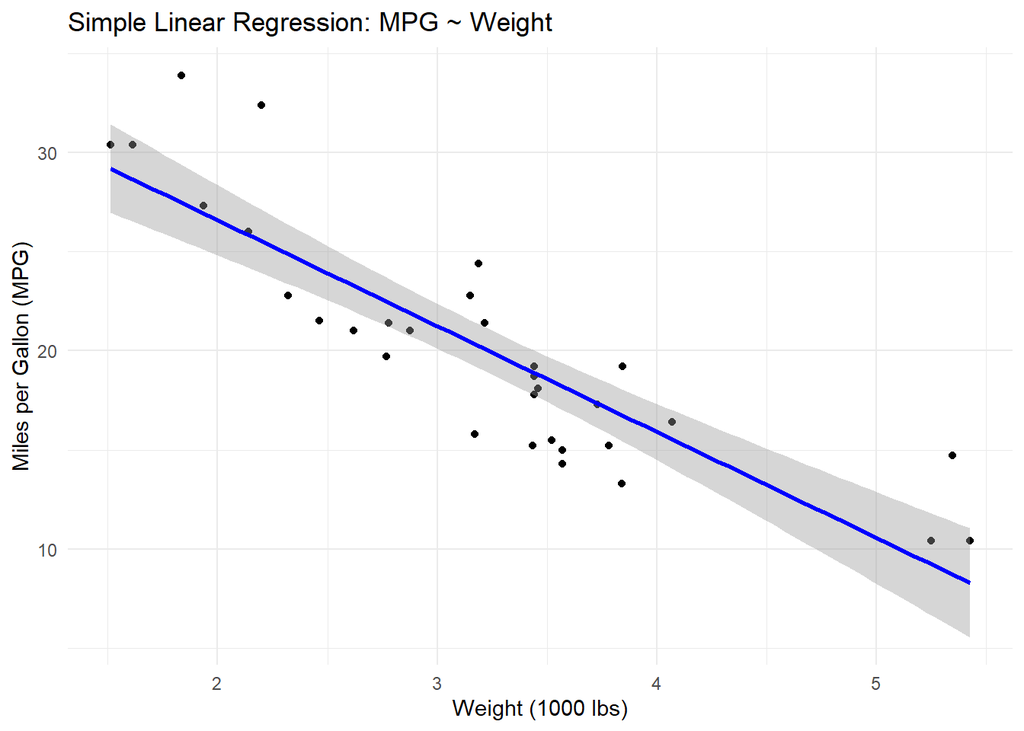

```r
library(ggplot2)

ggplot(mtcars, aes(x = wt, y = mpg)) +
  geom_point() +
  geom_smooth(method = "lm", color = "blue", se = TRUE) +
  labs(title = "Simple Linear Regression: MPG ~ Weight",
       x = "Weight (1000 lbs)",
       y = "Miles per Gallon (MPG)") +
  theme_minimal()
```

This visualization helps students understand regression as a **line of best fit**.

## 3.3 Our Simulated Case: Modeling GPA from Lifestyle Factors

We now return to Sara’s dataset. Her hypothesis is:

> “Students with higher sleep hours and more supervisor support tend to have higher GPAs.”

Let’s test this hypothesis using **multiple linear regression**, including `sleep_hours_per_night` and `supervisor_support` as predictors.

We will also include `gender` as a categorical predictor and later explore interaction effects.

### Build the regression model

```r
# Load libraries
library(dplyr)

# Fit a multiple regression model
model_gpa <- lm(gpa ~ sleep_hours_per_night + supervisor_support + gender, data = data)

# View model summary
summary(model_gpa)
```

```
##
## Call:
## lm(formula = gpa ~ sleep_hours_per_night + supervisor_support +
##     gender, data = data)
##
## Residuals:
##      Min       1Q   Median       3Q      Max
## -1.10811 -0.22345 -0.01845  0.24533  0.92524
##
## Coefficients:
##                        Estimate Std. Error t value Pr(>|t|)
## (Intercept)            2.898920   0.179471  16.153   <2e-16 ***
## sleep_hours_per_night -0.003178   0.022310  -0.142   0.8869
## supervisor_support     0.066845   0.027268   2.451   0.0151 *
## genderMale            -0.071519   0.054900  -1.303   0.1942
## ---
## Signif. codes:  0 '***' 0.001 '**' 0.01 '*' 0.05 '.' 0.1 ' ' 1
##
## Residual standard error: 0.3819 on 196 degrees of freedom
## Multiple R-squared:  0.03655,    Adjusted R-squared:  0.0218
## F-statistic: 2.478 on 3 and 196 DF,  p-value: 0.06248
```

This output tells us: - The **coefficient estimates** (e.g., how much GPA changes per hour of sleep) - Which predictors are **statistically significant** - The **R-squared** value (how much variance in GPA is explained by the model)

### 3.4 Interpreting Regression Output

Key things to look for in the summary:

- **Coefficients (`Estimate`)**: The direction and size of the effect
- **`Pr(>|t|)` (p-value)**: Whether the effect is statistically significant
- **`R-squared`**: Proportion of variability in GPA explained by the model
- **Residual standard error**: The average prediction error

# Part 4: Classification Analysis

In this section, we turn from continuous outcomes (like GPA) to **categorical classification problems**. Our outcome of interest is whether a student is **considering dropping out** — a binary variable.

## 4.1 Research Hypothesis

> “High stress and low supervisor support increase the likelihood of considering dropout.”

We will investigate whether we can **predict which students are at risk of dropout** using their stress levels, supervisor support, and other lifestyle or academic indicators.

## 4.2 Understanding Classification

**Classification** is the process of predicting which category or group a data point belongs to. In our case, we want to predict:

- `considering_dropout` = 0 (No)
- `considering_dropout` = 1 (Yes)

We will use both: - A **baseline logistic regression** model to demonstrate odds and interpretation. - **Advanced models**: Support Vector Machine (SVM) and Random Forests.

## 4.3 Preparing the Data

Before fitting models, ensure categorical variables are in proper format.

```r
# Convert gender to factor if not already
data$gender <- as.factor(data$gender)
data$considering_dropout <- as.factor(data$considering_dropout)

# View dropout distribution
table(data$considering_dropout)
```

```
##
##   0   1
## 173  27
```

## 4.4 Logistic Regression (Baseline)

We start with logistic regression as a baseline model.

```r
# Fit logistic regression model
model_logit <- glm(considering_dropout ~ stress_level + supervisor_support + sleep_hours_per_night,
                   data = data, family = "binomial")

# Model summary
summary(model_logit)
```

```
##
## Call:
## glm(formula = considering_dropout ~ stress_level + supervisor_support +
##     sleep_hours_per_night, family = "binomial", data = data)
##
## Coefficients:
##                       Estimate Std. Error z value Pr(>|z|)
## (Intercept)             0.9238     1.4436   0.640   0.5222
## stress_level           -0.1060     0.1137  -0.933   0.3509
## supervisor_support     -0.3729     0.2107  -1.769   0.0769 .
## sleep_hours_per_night  -0.1406     0.1741  -0.807   0.4194
## ---
## Signif. codes:  0 '***' 0.001 '**' 0.01 '*' 0.05 '.' 0.1 ' ' 1
##
## (Dispersion parameter for binomial family taken to be 1)
##
##     Null deviance: 158.31  on 199  degrees of freedom
## Residual deviance: 153.54  on 196  degrees of freedom
## AIC: 161.54
##
## Number of Fisher Scoring iterations: 5
```

### Interpreting Odds Ratios

```r
# Calculate odds ratios
exp(coef(model_logit))
```

```
##           (Intercept)          stress_level    supervisor_support
##             2.5187485             0.8994023             0.6887683
## sleep_hours_per_night
##             0.8688320
```

This helps us understand how each variable affects the odds of dropout: - Values >1 increase odds of dropout. - Values <1 decrease odds of dropout.

## 4.5 Classification with Support Vector Machines (SVM)

Support Vector Machines are powerful models for classification, especially when classes are not linearly separable.

```r
# Load library
library(e1071)
# Train SVM model
model_svm <- svm(considering_dropout ~ stress_level + supervisor_support + sleep_hours_per_night,
                 data = data, kernel = "radial", probability = TRUE)

# Predict on training data
svm_preds <- predict(model_svm, data, probability = TRUE)

# Confusion matrix
table(Predicted = svm_preds, Actual = data$considering_dropout)
```

```
##          Actual
## Predicted   0   1
##         0 173  26
##         1   0   1
```

## 4.6 Classification with Random Forest

Random Forest is a tree-based ensemble method that works well with mixed data types and nonlinear relationships.

```r
# Load library
library(randomForest)
# Train random forest model
model_rf <- randomForest(considering_dropout ~ stress_level + supervisor_support + sleep_hours_per_night,
                         data = data, ntree = 100, importance = TRUE)

# Predict and evaluate
rf_preds <- predict(model_rf, data)

# Confusion matrix
table(Predicted = rf_preds, Actual = data$considering_dropout)
```

```
##          Actual
## Predicted   0   1
##         0 173  22
##         1   0   5
```

### Variable Importance

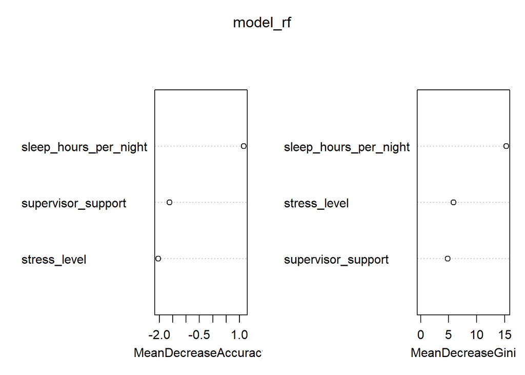

```r
# Plot variable importance
varImpPlot(model_rf)
```

This shows which variables were most influential in classifying students.

## 4.7 Model Performance and Accuracy Metrics

After training a classification model (SVM, Random Forest, Logistic Regression, etc.), we need to assess how well the model performs. This involves measuring the quality of its predictions compared to the true labels.

### Core Concept: The Confusion Matrix

A **confusion matrix** is a table that shows the performance of a classification model:

|  | Predicted No | Predicted Yes |
| --- | --- | --- |
| **Actual No** | TN (True Neg) | FP (False Pos) |
| **Actual Yes** | FN (False Neg) | TP (True Pos) |

From this, we derive the following key metrics:

### 1. Accuracy

The percentage of correct predictions out of all cases.

$$\text{Accuracy} = \frac{TP + TN}{TP + TN + FP + FN}$$

However, **accuracy can be misleading in imbalanced datasets**. For example, if 90% of students are not considering dropout, a model that always predicts “No” will have 90% accuracy but is useless.

### **2. Precision and Recall**

#### **Precision**: How many predicted positives were correct?

$$\text{Precision} = \frac{TP}{TP + FP}$$

High precision means **low false positives**.

#### **Recall (Sensitivity)**: How many actual positives were detected?

$$\text{Recall} = \frac{TP}{TP + FN}$$

High recall means **low false negatives**, which is crucial if your goal is to **catch at-risk students**.

### **3. F1 Score**

The harmonic mean of precision and recall. It balances both in one metric.

$$F1 = 2 \times \frac{\text{Precision} \times
\text{Recall}}{\text{Precision} + \text{Recall}}$$

### **4. ROC Curve and AUC (Area Under the Curve)**

The **ROC curve** plots the true positive rate vs. false positive rate for various thresholds.

- AUC = 1: perfect model
- AUC = 0.5: random guess
- AUC > 0.8: good model

## 🔧 Code: Evaluating Model Performance in R

Let’s apply these metrics to our **Random Forest model**:

```r
# Load packages
library(caret)
library(pROC)

# Create confusion matrix
conf_matrix <- confusionMatrix(rf_preds, data$considering_dropout, positive = "1")
conf_matrix
```

```
## Confusion Matrix and Statistics
##
##           Reference
## Prediction   0   1
##          0 173  22
##          1   0   5
##
##                Accuracy : 0.89
##                  95% CI : (0.8382, 0.9298)
##     No Information Rate : 0.865
##     P-Value [Acc > NIR] : 0.1766
##
##                   Kappa : 0.2822
##
##  Mcnemar's Test P-Value : 7.562e-06
##
##             Sensitivity : 0.1852
##             Specificity : 1.0000
##          Pos Pred Value : 1.0000
##          Neg Pred Value : 0.8872
##              Prevalence : 0.1350
##          Detection Rate : 0.0250
##    Detection Prevalence : 0.0250
##       Balanced Accuracy : 0.5926
##
##        'Positive' Class : 1
##
```

### Extracting precision, recall, F1

```r
# Confusion matrix details
conf_matrix$byClass[c("Precision", "Recall", "F1")]
```

```
## Precision    Recall        F1
## 1.0000000 0.1851852 0.3125000
```

## ROC Curve and AUC for SVM

To compute AUC, we need predicted probabilities, not just labels:

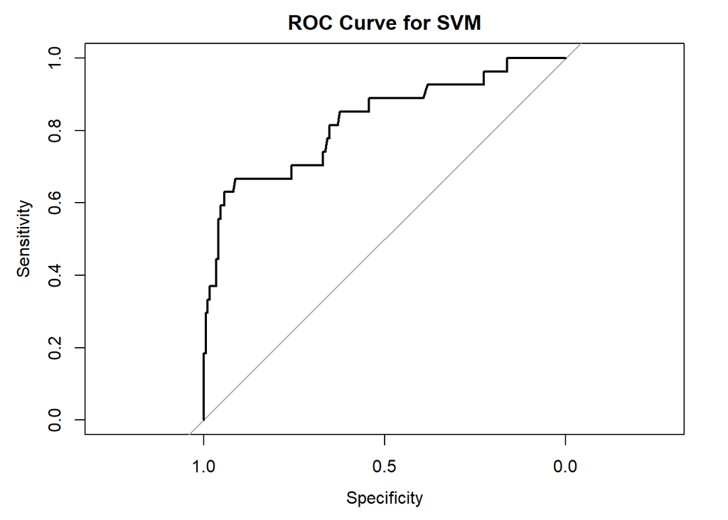

```r
# Predicted probabilities from SVM
svm_probs <- attr(predict(model_svm, data, probability = TRUE), "probabilities")[, "1"]

# Compute ROC and plot
roc_curve <- roc(response = data$considering_dropout, predictor = svm_probs)
plot(roc_curve, main = "ROC Curve for SVM")
```

```r
auc(roc_curve)
```

```
## Area under the curve: 0.8246
```

## Interpretation Tips for Research

When writing your thesis or report: - Use **accuracy only with caution** in imbalanced datasets. - Report **precision and recall** especially if **false negatives are costly** (e.g., missing at-risk students). - Use **AUC** to compare models (higher is better). - Justify model choice based not only on performance but also **interpretability and ethical context**.

# Part 5: Clustering and Pattern Discovery

Clustering is an unsupervised machine learning technique used to discover **groups or patterns** in data without predefined labels. It is especially useful in exploratory research when you want to identify subpopulations or behavioral profiles.

## 5.1 Research Objective

> “Are there distinct lifestyle-academic profiles among students?”

We aim to group students based on behavioral and academic factors such as: - Study habits - Sleep duration - Physical activity - Caffeine use - Stress and GPA

These groups can reveal insights like “low GPA, high stress” vs. “balanced lifestyle, high GPA” profiles.

## 5.2 Preparing the Data

Clustering algorithms, especially **K-means**, are sensitive to variable scales. We must: - Select numeric variables only - Remove missing values - Scale (normalize) the data

```r
library(dplyr)

# Select relevant continuous variables
cluster_vars <- data %>%
  select(study_hours_per_week, sleep_hours_per_night,
         exercise_freq_per_week, caffeine_intake_mg,
         stress_level, gpa) %>%
  na.omit()

# Scale the data
cluster_scaled <- scale(cluster_vars)
```

## 5.3 Determining the Optimal Number of Clusters

We’ll use two common methods to help decide how many clusters (k) to use:

### 1. Elbow Method

This method looks for the “elbow point” where adding more clusters doesn’t significantly improve the within-cluster variance.

```r
library(factoextra)
```

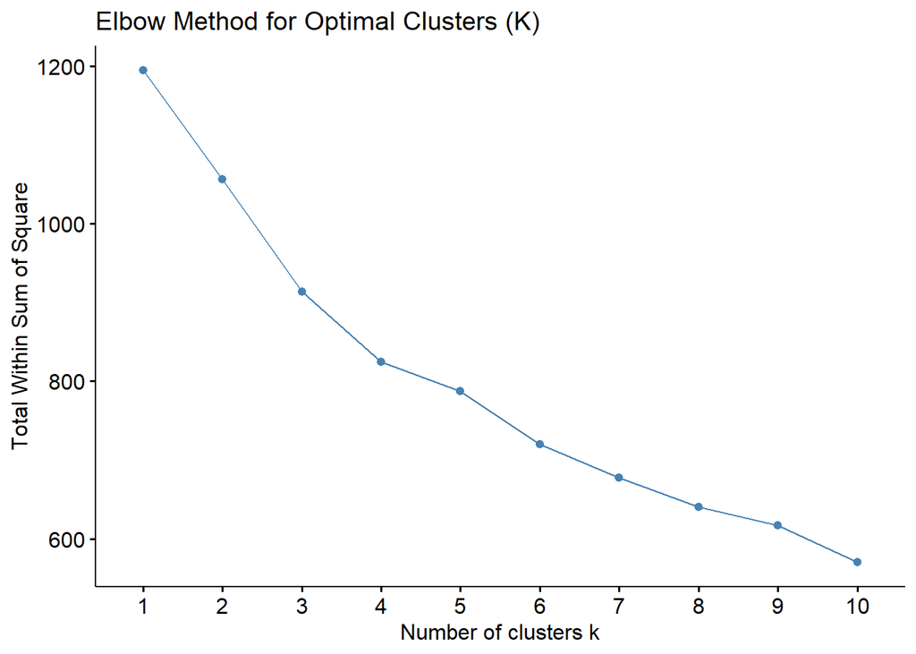

```r
# Elbow method visualization
fviz_nbclust(cluster_scaled, kmeans, method = "wss") +
  labs(title = "Elbow Method for Optimal Clusters (K)")
```

### 2. Silhouette Method

This measures how similar each data point is to its own cluster compared to others. A higher average silhouette width indicates better-defined clusters.

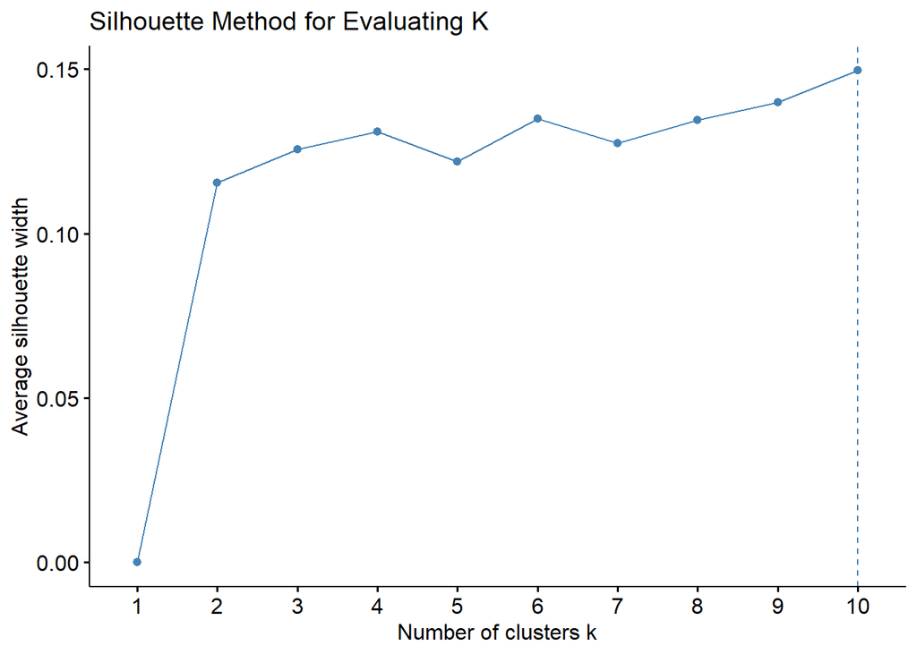

```r
fviz_nbclust(cluster_scaled, kmeans, method = "silhouette") +
  labs(title = "Silhouette Method for Evaluating K")
```

## 5.4 Performing K-Means Clustering

```r
# Set seed for reproducibility
set.seed(123)

# Apply K-means with 3 clusters
kmeans_model <- kmeans(cluster_scaled, centers = 3, nstart = 25)

# View cluster assignments
table(kmeans_model$cluster)
```

```
##
##  1  2  3
## 68 61 71
```

## 5.5 Visualizing K-Means Clusters

We use `fviz_cluster()` to plot the clustering results and see how students group together based on the variables we selected.

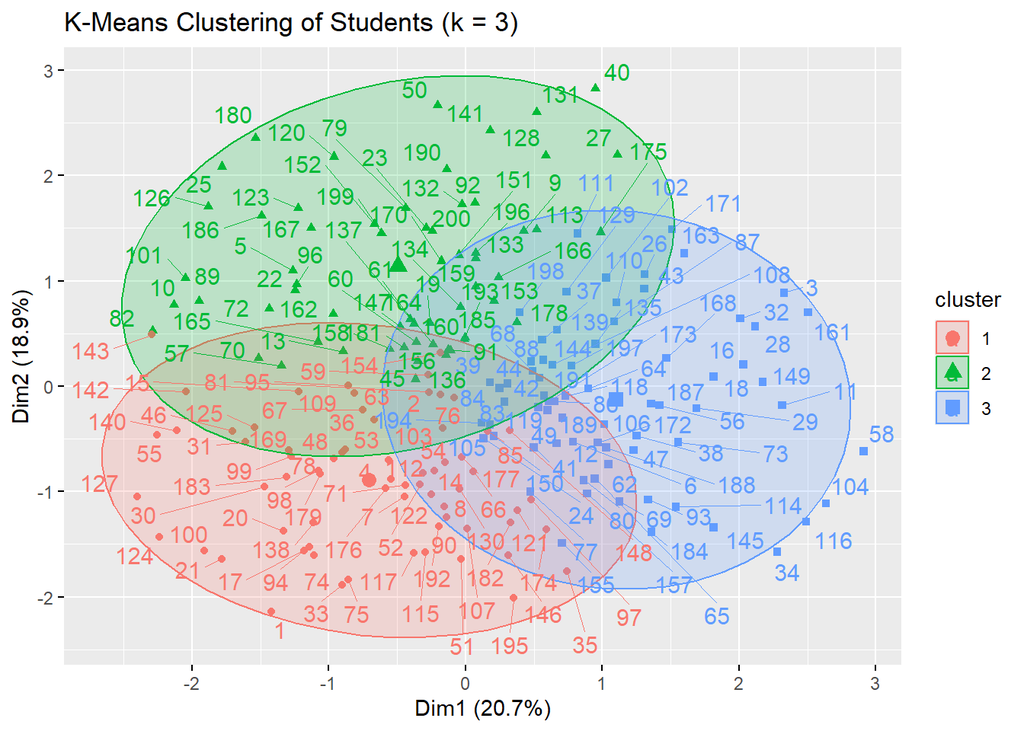

```r
fviz_cluster(kmeans_model, data = cluster_scaled,
             ellipse.type = "norm",
             main = "K-Means Clustering of Students (k = 3)",
             repel = TRUE)
```

## 5.6 Interpreting the Clusters

To understand what each cluster represents, we can **add cluster labels** to the original data and examine average characteristics per cluster.

```r
# Add cluster label to unscaled data
clustered_data <- cluster_vars
clustered_data$cluster <- factor(kmeans_model$cluster)

# Summarize by cluster
cluster_summary <- clustered_data %>%
  group_by(cluster) %>%
  summarise(across(everything(), mean, .names = "avg_{.col}"))

cluster_summary
```

```
## # A tibble: 3 × 7
##   cluster avg_study_hours_per_week avg_sleep_hours_per_…¹ avg_exercise_freq_pe…²
##   <fct>                      <dbl>                  <dbl>                  <dbl>
## 1 1                           28.2                   5.80                   1.60
## 2 2                           25.3                   7.18                   3.95
## 3 3                           22.5                   6.39                   2.41
## # ℹ abbreviated names: ¹avg_sleep_hours_per_night, ²avg_exercise_freq_per_week
## # ℹ 3 more variables: avg_caffeine_intake_mg <dbl>, avg_stress_level <dbl>,
## #   avg_gpa <dbl>
```

## 5.7 Bonus: Hierarchical Clustering

We can also use **hierarchical clustering** to visualize relationships between students using a dendrogram.

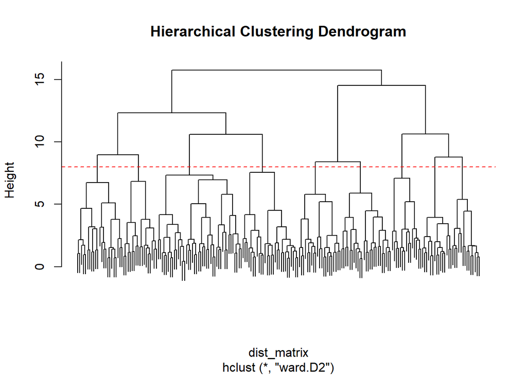

```r
# Compute distance matrix
dist_matrix <- dist(cluster_scaled)

# Apply hierarchical clustering
hclust_model <- hclust(dist_matrix, method = "ward.D2")

# Plot the dendrogram
plot(hclust_model, labels = FALSE, main = "Hierarchical Clustering Dendrogram")
abline(h = 8, col = "red", lty = 2)  # Example cut line
```

# Part 6: Dimensionality Reduction

In many datasets, particularly those involving **psychological or survey data**, variables can be highly correlated. For example, high stress may co-occur with burnout and low satisfaction. In such cases, it is useful to **reduce the dimensionality** of the data while preserving the essential patterns.

## 6.1 Research Objective

> “Can we reduce psychological variables into latent wellbeing components?”

Rather than analyzing stress, burnout, and satisfaction separately, we want to discover **underlying dimensions** such as “mental strain” or “academic wellbeing” that explain most of the variation in the data.

## 6.2 What is Principal Component Analysis (PCA)?

**PCA** is a mathematical technique that transforms correlated variables into a smaller number of uncorrelated variables called **principal components** (PCs). Each principal component is a **linear combination** of the original variables.

Key goals: - **Reduce noise and redundancy** - **Visualize complex data in fewer dimensions** - **Identify latent constructs**

## 6.3 Variables for PCA

We’ll use three psychological indicators from the dataset: - `stress_level` - `burnout_level` - `satisfaction_academic`

## 6.4 Running PCA on the Dataset

First, we select and scale the relevant variables.

```r
# Load required library
library(factoextra)

# Select and scale relevant variables
pca_vars <- data %>%
  select(stress_level, burnout_level, satisfaction_academic) %>%
  na.omit()

pca_scaled <- scale(pca_vars)
```

## 6.5 Performing PCA

We now run PCA on the scaled variables.

```r
# Run PCA
pca_result <- prcomp(pca_scaled, center = TRUE, scale. = TRUE)

# View PCA results
summary(pca_result)
```

```
## Importance of components:
##                           PC1    PC2    PC3
## Standard deviation     1.0455 0.9990 0.9534
## Proportion of Variance 0.3644 0.3327 0.3030
## Cumulative Proportion  0.3644 0.6970 1.0000
```

The summary shows: - **Standard deviation** of each principal component - **Proportion of variance** explained by each PC - **Cumulative proportion** — how many components explain a sufficient portion of total variance

## 6.6 Visualizing PCA Results

### Scree Plot: How much variance each component explains

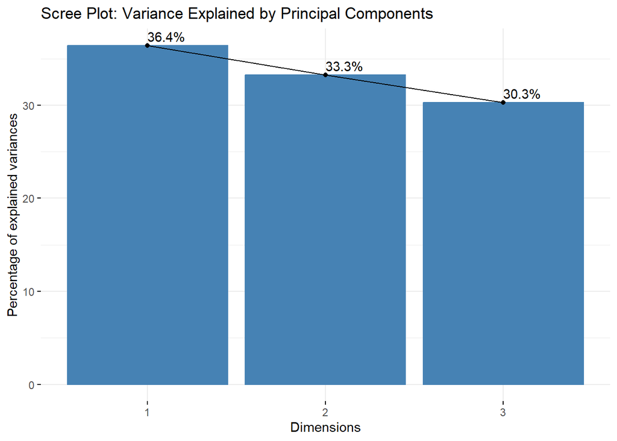

```r
fviz_eig(pca_result, addlabels = TRUE, barfill = "steelblue") +
  labs(title = "Scree Plot: Variance Explained by Principal Components")
```

### Contribution of Each Variable to PCs

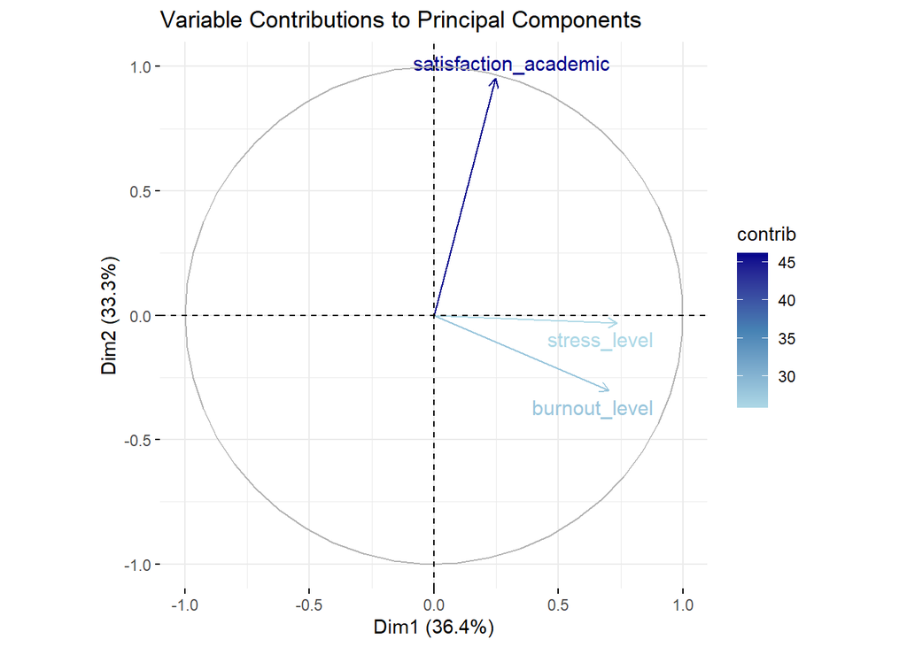

```r
fviz_pca_var(pca_result, col.var = "contrib",
             gradient.cols = c("lightblue", "steelblue", "darkblue"),
             repel = TRUE) +
  labs(title = "Variable Contributions to Principal Components")
```

This plot helps interpret the **loadings** — how much each original variable contributes to the principal components: - PC1 may represent **psychological strain** - PC2 might capture **academic satisfaction**

## 6.7 Projecting Individuals (Optional)

You can also project each student (individual) onto the PC space.

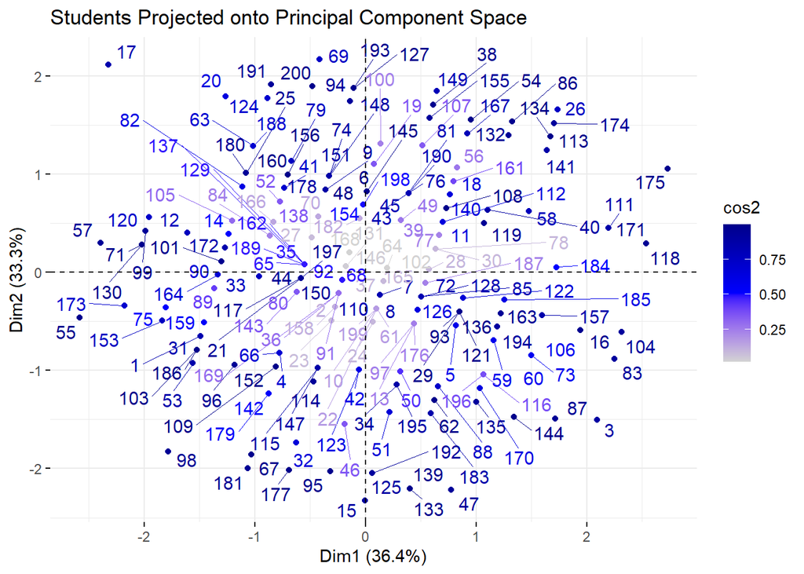

```r
fviz_pca_ind(pca_result,
             col.ind = "cos2", # color by quality of representation
             gradient.cols = c("lightgray", "blue", "darkblue"),
             repel = TRUE) +
  labs(title = "Students Projected onto Principal Component Space")
```

This visualization can help you cluster or segment students based on their psychological profiles.

## 6.8 Interpretation in Research

In your thesis, PCA allows you to: - Reduce dimensionality before clustering or regression - Build **composite wellbeing indices** - Interpret latent constructs (e.g., mental strain, engagement)

You can also use PCA as a **preprocessing step** to reduce multicollinearity in predictive models.

# Part 7: Reproducible Research and Ethical Modeling

One of the most important (and often overlooked) aspects of data analysis is not just conducting the analysis, but **documenting it clearly** and **sharing it responsibly**. This ensures that others can verify, reproduce, and build upon your findings — a core principle of scientific integrity.

## 7.1 Reproducible Research with R Markdown

**Reproducible research** means that anyone with access to your code and data can **run your analysis and get the same results**.

**R Markdown** supports reproducibility by combining: - Narrative text (your explanations and interpretations) - R code (your analysis) - Output (tables, plots, summaries)

All in one dynamic document.

Benefits: - Transparency - Easier collaboration with supervisors or peers - Faster review and publication processes

### Example Header in R Markdown

```yaml
---
title: "Sara's Thesis Data Analysis"
author: "Sara Ahmed"
output: html_document
---
```

### Best Practices for Reproducibility

- Always **set a seed** for randomness (e.g., `set.seed(123)`)
- Include **all data cleaning and transformation steps**
- Use **relative paths** and consistent folder structures
- Label code chunks clearly and avoid overly long scripts

## 7.2 Ethical Considerations in Data Modeling

Beyond technical quality, every research project must consider **ethical implications** in how data is used, shared, and interpreted.

### 1. **Bias in Modeling**

Models may reflect or even amplify existing biases if not properly evaluated.

Examples: - Using GPA as the only measure of success may disadvantage students with learning differences. - Models trained on unbalanced data can misclassify underrepresented groups.

#### Mitigation strategies:

- Analyze model performance across subgroups (e.g., gender)
- Report fairness metrics (e.g., equal opportunity, demographic parity)
- Avoid using sensitive attributes (e.g., race, religion) as predictors without justification

### 2. **Privacy and Data Security**

Respect for participant privacy is a fundamental research principle. This includes:

- Removing personally identifiable information (PII)
- Masking or anonymizing student IDs before sharing
- Not publishing raw datasets without consent or clearance

If sharing data, always check with: - University data governance guidelines - Ethical review board policies - Informed consent agreements

### 3. **Responsible Code Sharing**

If you publish your thesis or results online: - Include a `README.md` explaining the purpose of the scripts - Host code in a public or private Git repository (e.g., GitHub, GitLab) - Share only derived or anonymized data when allowed

Licensing your code with an open license (e.g., MIT, GPL) also helps others reuse it properly.

## 7.3 Summary and Recommendations

| Topic | Recommendation |
| --- | --- |
| Documentation | Use R Markdown to combine code, text, and results |
| Bias | Analyze subgroup performance, avoid unfair features |
| Privacy | Never share raw personal data without safeguards |
| Sharing | Use Git, comment code, and follow open science practices |

By integrating **rigorous documentation** with **ethical responsibility**, your analysis becomes not only statistically valid, but also scientifically trustworthy and socially responsible.

# Part 8: Beyond R — Other Tools for Data Analysis

While R is a powerful and open-source language for data analysis, it is not the only option available to researchers. Depending on the project scope, field of study, available resources, and the user’s background, other tools might be more suitable for certain types of analysis or visualization. This section introduces key alternatives and their unique strengths.

## 1. Python Ecosystem

**Python** has become one of the most popular languages in data science. Its rich ecosystem of libraries makes it highly flexible for everything from data wrangling to deep learning.

[figure not shown]

### Use Cases

- Data preprocessing and analysis (Pandas)
- Statistical learning and classification (scikit-learn)
- Visualization and reporting (Seaborn, Matplotlib)
- Natural language processing and neural networks (TensorFlow, PyTorch)

### Pros

- Widely used in industry and research
- Extensive online support and documentation
- Integrates well with APIs, databases, and web apps

### Cons

- Steeper learning curve than GUI-based tools
- Requires coding environment setup

## 2. Weka

**Weka** is a beginner-friendly, GUI-based platform developed at the University of Waikato for teaching and prototyping machine learning.

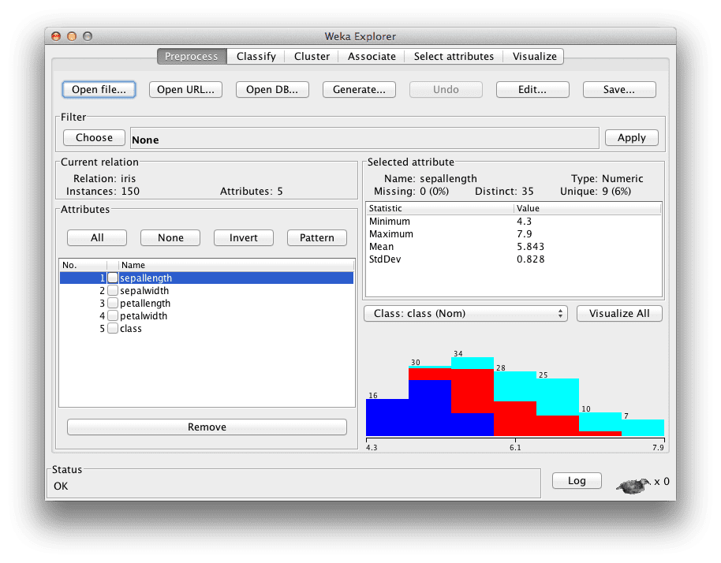

Weka

### Use Cases

- Rapid prototyping of classifiers
- Educational use for teaching ML concepts
- Evaluating performance of models on clean datasets

### Pros

- Intuitive interface with no coding required
- Useful visualizations and evaluation tools
- Extensive built-in algorithms

### Cons

- Limited scalability for large datasets
- Not ideal for advanced research or deployment

## 3. GNU Octave

**GNU Octave** is a high-level interpreted language, mostly compatible with MATLAB, used mainly for numerical computations.

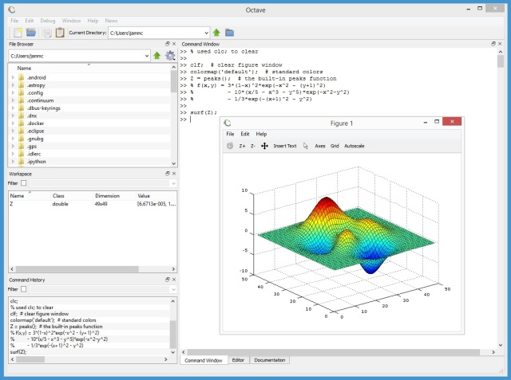

GNU Octave

### Use Cases

- Engineering simulations
- Linear algebra, calculus, and control systems
- MATLAB-compatible environments for academia

### Pros

- Free and open source
- Great for academic and teaching use
- Useful for scripting numerical solutions

### Cons

- Less intuitive for data analysis tasks compared to R or Python
- Slower performance for large-scale simulations

## 4. SPSS

**SPSS** is a GUI-based software package from IBM, widely used in social sciences for statistical analysis and data management.

[figure not shown]

SPSS

### Use Cases

- Survey data analysis
- Psychometric and sociological research
- Government and healthcare analytics

### Pros

- No coding required
- Well-documented procedures
- Reliable output format for publication

### Cons

- Commercial license required (expensive)
- Limited customization and automation

## 5. Stata

**Stata** is widely used in fields like economics, biostatistics, and epidemiology for its strong statistical modeling capabilities.

[figure not shown]

Stata

### Use Cases

- Time-series analysis
- Panel and survival data
- Healthcare and clinical trials

### Pros

- Strong documentation and academic user base
- Powerful built-in statistics and econometrics tools

### Cons

- Proprietary and costly
- Less flexible for modern machine learning

## 6. Jamovi

**Jamovi** is a user-friendly, open-source alternative to SPSS that is built on top of R. It offers a point-and-click interface while retaining full access to R scripting for advanced users.

[figure not shown]

Jamovi

### Use Cases

- Teaching statistics
- Small-scale research studies
- Psychological testing and basic hypothesis testing

### Pros

- Modern and simple interface
- Free and open source
- Supports reproducibility and R transparency

### Cons

- Still evolving, some limitations in advanced methods
- Dependent on the R backend

## 7. JASP

**JASP** is an open-source alternative to SPSS with a special focus on **Bayesian statistics**. It is increasingly used in psychology and social sciences.

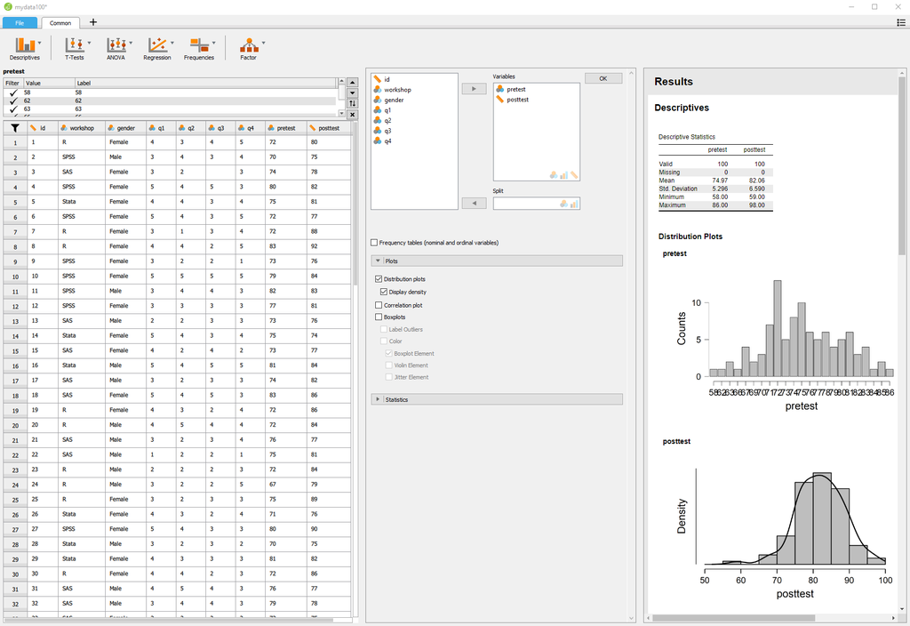

JASP

### Use Cases

- Bayesian modeling
- Exploratory factor analysis
- Basic to intermediate statistical tests

### Pros

- Focuses on ease of use
- Supports frequentist and Bayesian approaches
- Highly reproducible via JASP output files

### Cons

- Less flexible than R or Python
- Limited to what’s available in the GUI

## 8. Tableau

**Tableau** is a leading business intelligence and data visualization platform, used to turn data into interactive dashboards and compelling visuals.

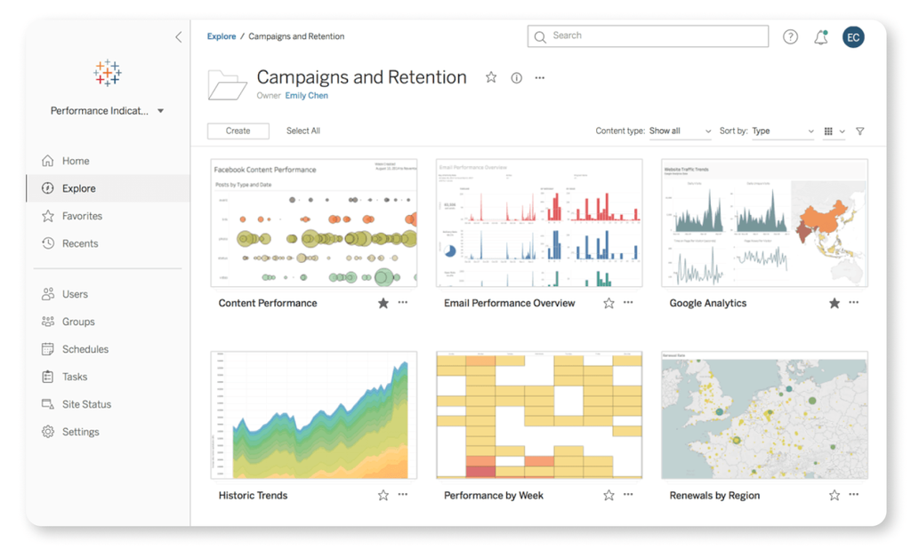

Tableau

### Use Cases

- Real-time dashboards
- Business analytics and KPI tracking
- Executive reporting and presentations

### Pros

- Drag-and-drop interface
- Rich visual library
- Real-time data connections

### Cons

- Commercial license required
- Less suited for statistical modeling

## 9. Microsoft Power BI

**Microsoft Power BI** is a powerful data visualization tool designed for business intelligence, with deep integration across Microsoft Office tools.

[figure not shown]

Power BI

### Use Cases

- Real-time dashboards for executives
- Integration with Excel and SQL Server
- Financial and business reporting

### Pros

- Seamless integration with Microsoft ecosystem
- Strong data connector options (SharePoint, Azure, etc.)
- Free desktop version

### Cons

- Limited statistical functionality
- Report sharing restricted without a Pro license

## Choosing the Right Tool

| Tool | Best For | Notes |
| --- | --- | --- |
| R | Academic data analysis and stats | Open-source, rich packages |
| Python | Machine learning, automation, flexibility | Powerful and widely supported |
| SPSS/Stata | Social science and economic modeling | GUI-based but expensive |
| Jamovi/JASP | Stats education and Bayesian analysis | Good for reproducibility |
| Tableau/Power BI | Interactive dashboards and business reporting | Best for storytelling and exec reports |
| Octave | Engineering and math modeling | MATLAB compatibility for free |
| Weka | Teaching machine learning | Great for non-coders, limited scalability |

*All images shown are for educational purposes only and remain the property of their respective owners.*